# Prediction Assignment Writeup

Carlos Henrique

11/11/2020

## Executive summary

First, it is made an exploratory data analysis to get to know better the data we’re dealing with. With regard to the cross validation, the provided training dataset, after having been properly treated (cleaned), was under subsampling, randomly and without replacement. The result was two subsamples, training_training (75% of the original data) and training_testing (25% of it). Thus, the two models were fitted within the training_training and tested under training_testing. As for the expected out-of-sample error, it is the error rate one gets on a new data set, also called generalization error. In mathematical terms, it is given by 1 - accuracy in the cross validation dataset. The expected out-of-sample error was about 0.5% for the Random Forest model. Afterwards, it is tested two models for prediction, Decision Tree and Random Forest. We found that Random Forest model provided the biggest accuracy, which is why was the chosen for the final model.

## Description of the data

The data was extracted from a research on the measurement of not only how much people do activities but also how well they do it. In order to collect these data (i.e. Weight Lifting Exercises Dataset) the researchers made an experiment in which they asked six male participants aged between 20-28 years old to perform one set of 10 repetitions of the Unilateral Dumbbell Biceps Curl in 5 different fashions: exactly according to the specification (Class A), throwing the elbows to the front (Class B), lifting the dumbbell only halfway (Class C), lowering the dumbbell only halfway (Class D) and throwing the hips to the front (Class E). In short, Class A corresponds to the specified execution of the exercise, whereas the other remaining four to the common mistakes (thus proxies to measure the quality of the exercise).

The aim of this project is to predict the manner in which a set of six male participants did the required exercise. This is the “classe” variable in the training set. You may use any of the other variables to predict with. You should create a report describing how you built your model, how you used cross validation, what you think the expected out of sample error is, and why you made the choices you did. You will also use your prediction model to predict 20 different test cases.

## Loading packages and the dataset

```r
set.seed(1234)

library(randomForest); library(caret); library(rpart); library(ggplot2); library(lattice); library(rpart.plot); library(rattle)
training <- read.csv("pml-training.csv", na.strings = c("NA", "#DIV/0!", ""))
testing <- read.csv("pml-testing.csv", na.strings = c("NA", "#DIV/0!", ""))
```

## Exploratory data analysis

As there is a lot of information provided by the data set, the exploratory analysis is only made for the training data for an example.

```r
dim(training); summary(training); str(training)
```

```
## [1] 19622   160
```

```
##        X            user_name    raw_timestamp_part_1 raw_timestamp_part_2
##  Min.   :    1   adelmo  :3892   Min.   :1.322e+09    Min.   :   294
##  1st Qu.: 4906   carlitos:3112   1st Qu.:1.323e+09    1st Qu.:252912
##  Median : 9812   charles :3536   Median :1.323e+09    Median :496380
##  Mean   : 9812   eurico  :3070   Mean   :1.323e+09    Mean   :500656
##  3rd Qu.:14717   jeremy  :3402   3rd Qu.:1.323e+09    3rd Qu.:751891
##  Max.   :19622   pedro   :2610   Max.   :1.323e+09    Max.   :998801
##
##           cvtd_timestamp  new_window    num_window      roll_belt
##  28/11/2011 14:14: 1498   no :19216   Min.   :  1.0   Min.   :-28.90
##  05/12/2011 11:24: 1497   yes:  406   1st Qu.:222.0   1st Qu.:  1.10
##  30/11/2011 17:11: 1440               Median :424.0   Median :113.00
##  05/12/2011 11:25: 1425               Mean   :430.6   Mean   : 64.41
##  02/12/2011 14:57: 1380               3rd Qu.:644.0   3rd Qu.:123.00
##  02/12/2011 13:34: 1375               Max.   :864.0   Max.   :162.00
##  (Other)         :11007
##    pitch_belt          yaw_belt       total_accel_belt kurtosis_roll_belt
##  Min.   :-55.8000   Min.   :-180.00   Min.   : 0.00    Min.   :-2.121
##  1st Qu.:  1.7600   1st Qu.: -88.30   1st Qu.: 3.00    1st Qu.:-1.329
##  Median :  5.2800   Median : -13.00   Median :17.00    Median :-0.899
##  Mean   :  0.3053   Mean   : -11.21   Mean   :11.31    Mean   :-0.220
##  3rd Qu.: 14.9000   3rd Qu.:  12.90   3rd Qu.:18.00    3rd Qu.:-0.219
##  Max.   : 60.3000   Max.   : 179.00   Max.   :29.00    Max.   :33.000
##                                                        NA's   :19226
##  kurtosis_picth_belt kurtosis_yaw_belt skewness_roll_belt skewness_roll_belt.1
##  Min.   :-2.190      Mode:logical      Min.   :-5.745     Min.   :-7.616
##  1st Qu.:-1.107      NA's:19622        1st Qu.:-0.444     1st Qu.:-1.114
##  Median :-0.151                        Median : 0.000     Median :-0.068
##  Mean   : 4.334                        Mean   :-0.026     Mean   :-0.296
##  3rd Qu.: 3.178                        3rd Qu.: 0.417     3rd Qu.: 0.661
##  Max.   :58.000                        Max.   : 3.595     Max.   : 7.348
##  NA's   :19248                         NA's   :19225      NA's   :19248
##  skewness_yaw_belt max_roll_belt     max_picth_belt   max_yaw_belt
##  Mode:logical      Min.   :-94.300   Min.   : 3.00   Min.   :-2.10
##  NA's:19622        1st Qu.:-88.000   1st Qu.: 5.00   1st Qu.:-1.30
##                    Median : -5.100   Median :18.00   Median :-0.90
##                    Mean   : -6.667   Mean   :12.92   Mean   :-0.22
##                    3rd Qu.: 18.500   3rd Qu.:19.00   3rd Qu.:-0.20
##                    Max.   :180.000   Max.   :30.00   Max.   :33.00
##                    NA's   :19216     NA's   :19216   NA's   :19226
```

[output cut: 281 more lines]

```
##  Min.   : -7.02000   Min.   : -8.0900   Min.   :-498.00   Min.   :-632.0
##  1st Qu.: -1.46000   1st Qu.: -0.1800   1st Qu.:-178.00   1st Qu.:  57.0
##  Median :  0.03000   Median :  0.0800   Median : -57.00   Median : 201.0
##  Mean   :  0.07517   Mean   :  0.1512   Mean   : -61.65   Mean   : 163.7
##  3rd Qu.:  1.62000   3rd Qu.:  0.4900   3rd Qu.:  76.00   3rd Qu.: 312.0
##  Max.   :311.00000   Max.   :231.0000   Max.   : 477.00   Max.   : 923.0
##
##  accel_forearm_z   magnet_forearm_x  magnet_forearm_y magnet_forearm_z classe
##  Min.   :-446.00   Min.   :-1280.0   Min.   :-896.0   Min.   :-973.0   A:5580
##  1st Qu.:-182.00   1st Qu.: -616.0   1st Qu.:   2.0   1st Qu.: 191.0   B:3797
##  Median : -39.00   Median : -378.0   Median : 591.0   Median : 511.0   C:3422
##  Mean   : -55.29   Mean   : -312.6   Mean   : 380.1   Mean   : 393.6   D:3216
##  3rd Qu.:  26.00   3rd Qu.:  -73.0   3rd Qu.: 737.0   3rd Qu.: 653.0   E:3607
##  Max.   : 291.00   Max.   :  672.0   Max.   :1480.0   Max.   :1090.0
##
```

```
## 'data.frame':    19622 obs. of  160 variables:
##  $ X                       : int  1 2 3 4 5 6 7 8 9 10 ...
##  $ user_name               : Factor w/ 6 levels "adelmo","carlitos",..: 2 2 2 2 2 2 2 2 2 2 ...
##  $ raw_timestamp_part_1    : int  1323084231 1323084231 1323084231 1323084232 1323084232 1323084232 1323084232 1323084232 1323084232 1323084232 ...
##  $ raw_timestamp_part_2    : int  788290 808298 820366 120339 196328 304277 368296 440390 484323 484434 ...
##  $ cvtd_timestamp          : Factor w/ 20 levels "02/12/2011 13:32",..: 9 9 9 9 9 9 9 9 9 9 ...
##  $ new_window              : Factor w/ 2 levels "no","yes": 1 1 1 1 1 1 1 1 1 1 ...
##  $ num_window              : int  11 11 11 12 12 12 12 12 12 12 ...
##  $ roll_belt               : num  1.41 1.41 1.42 1.48 1.48 1.45 1.42 1.42 1.43 1.45 ...
##  $ pitch_belt              : num  8.07 8.07 8.07 8.05 8.07 8.06 8.09 8.13 8.16 8.17 ...
##  $ yaw_belt                : num  -94.4 -94.4 -94.4 -94.4 -94.4 -94.4 -94.4 -94.4 -94.4 -94.4 ...
##  $ total_accel_belt        : int  3 3 3 3 3 3 3 3 3 3 ...
##  $ kurtosis_roll_belt      : num  NA NA NA NA NA NA NA NA NA NA ...
##  $ kurtosis_picth_belt     : num  NA NA NA NA NA NA NA NA NA NA ...
##  $ kurtosis_yaw_belt       : logi  NA NA NA NA NA NA ...
```

[output cut: 86 more lines]

As we can see above, the data is made up of a lot of variables (160) and 19,622 observations for the training dataset and 20 for the testing one. The variable of interest, the output variable, is going to be “classe”.

Taking a look at the structure of the data, one can see the huge amount of not available values, thus being necessary to exclude the columns containing only them.

```r
training <- training[, colSums(is.na(training)) == 0]
testing <- testing[, colSums(is.na(testing)) == 0]
```

So now there are only 60 variables left for each dataset (that is, minus 100 variables).

```r
str(training)
```

```
## 'data.frame':    19622 obs. of  60 variables:
##  $ X                   : int  1 2 3 4 5 6 7 8 9 10 ...
##  $ user_name           : Factor w/ 6 levels "adelmo","carlitos",..: 2 2 2 2 2 2 2 2 2 2 ...
##  $ raw_timestamp_part_1: int  1323084231 1323084231 1323084231 1323084232 1323084232 1323084232 1323084232 1323084232 1323084232 1323084232 ...
##  $ raw_timestamp_part_2: int  788290 808298 820366 120339 196328 304277 368296 440390 484323 484434 ...
##  $ cvtd_timestamp      : Factor w/ 20 levels "02/12/2011 13:32",..: 9 9 9 9 9 9 9 9 9 9 ...
##  $ new_window          : Factor w/ 2 levels "no","yes": 1 1 1 1 1 1 1 1 1 1 ...
##  $ num_window          : int  11 11 11 12 12 12 12 12 12 12 ...
##  $ roll_belt           : num  1.41 1.41 1.42 1.48 1.48 1.45 1.42 1.42 1.43 1.45 ...
##  $ pitch_belt          : num  8.07 8.07 8.07 8.05 8.07 8.06 8.09 8.13 8.16 8.17 ...
##  $ yaw_belt            : num  -94.4 -94.4 -94.4 -94.4 -94.4 -94.4 -94.4 -94.4 -94.4 -94.4 ...
##  $ total_accel_belt    : int  3 3 3 3 3 3 3 3 3 3 ...
##  $ gyros_belt_x        : num  0 0.02 0 0.02 0.02 0.02 0.02 0.02 0.02 0.03 ...
##  $ gyros_belt_y        : num  0 0 0 0 0.02 0 0 0 0 0 ...
##  $ gyros_belt_z        : num  -0.02 -0.02 -0.02 -0.03 -0.02 -0.02 -0.02 -0.02 -0.02 0 ...
```

[output cut: 46 more lines]

Taking a look at the structure of the data above, one can see that there are plenty of useless variables for the project (specific information about the elements involved in the experiment, but nothing to do with the performance of the participants, which is specifically what we want). In this sense, yet other variables may be excluded, such as those of the first seven columns.

```r
training <- training[, -c(1:7)]
testing <- testing[, -c(1:7)]
```

Having appropriately cleaned the data, it’s time to partition the training dataset into 75% of training and the 25% left into testing, which is given as follows:

```r
inTrain <- createDataPartition(y = training$classe, p = .75, list = F)
training_training <- training[inTrain, ]
training_testing <- training[-inTrain, ]
```

As one can see on the structure of the data above, the aforementioned outcome variable, “classe”, consists of 5 levels (A, B, C, D, E). To get to know better the frequency of each classe, it’s desirable to take a look at a plot.

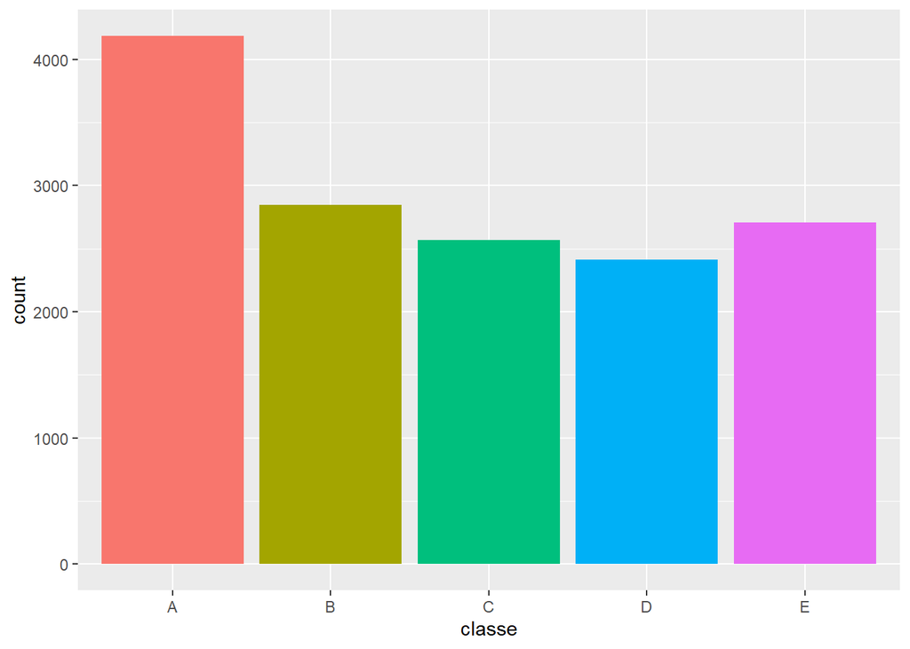

```r
ggplot(data = training_training) + geom_bar(mapping = aes(x = classe, fill = classe), show.legend = F)
```

This plot allows us to see that except for class A (according to specification), the common mistakes (the other classes) have approximately the same frequency.

## Decision tree

In order to assess the machine learning algorithm for prediction, decision tree method is used. This model was chosen because some of its pros are the ease of interpreting as well as the better performance in nonlinear settings.

```r
model_tree <- rpart(classe ~ ., data = training_training, method = "class")
prediction_tree <- predict(model_tree, training_testing, type = "class")
```

For the sake of visualization, the resulting plot is as follows:

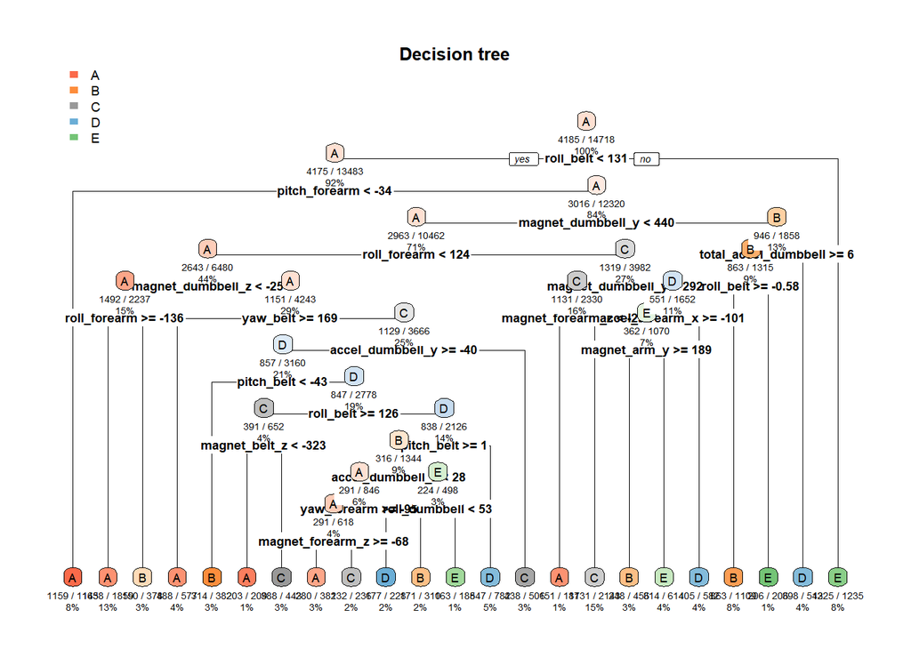

```r
rpart.plot(model_tree, main = "Decision tree", extra = 102, under = T, faclen = 0, cex = .55)
```

Though the plot has too much of information, we still can make use of the confusion matrix, so as to visualize the performance of the algorithm within the testing dataset.

```r
confusionMatrix(prediction_tree, training_testing$classe)
```

```
## Confusion Matrix and Statistics
##
##           Reference
## Prediction    A    B    C    D    E
##          A 1235  157   16   50   20
##          B   55  568   73   80  102
##          C   44  125  690  118  116
##          D   41   64   50  508   38
##          E   20   35   26   48  625
##
## Overall Statistics
##
##                Accuracy : 0.7394
##                  95% CI : (0.7269, 0.7516)
##     No Information Rate : 0.2845
##     P-Value [Acc > NIR] : < 2.2e-16
##
##                   Kappa : 0.6697
##
##  Mcnemar's Test P-Value : < 2.2e-16
##
## Statistics by Class:
##
##                      Class: A Class: B Class: C Class: D Class: E
## Sensitivity            0.8853   0.5985   0.8070   0.6318   0.6937
## Specificity            0.9307   0.9216   0.9005   0.9529   0.9678
## Pos Pred Value         0.8356   0.6469   0.6313   0.7247   0.8289
## Neg Pred Value         0.9533   0.9054   0.9567   0.9296   0.9335
## Prevalence             0.2845   0.1935   0.1743   0.1639   0.1837
## Detection Rate         0.2518   0.1158   0.1407   0.1036   0.1274
## Detection Prevalence   0.3014   0.1790   0.2229   0.1429   0.1538
## Balanced Accuracy      0.9080   0.7601   0.8537   0.7924   0.8307
```

So, all of biggest values in each column of the matrix coincide with the actual-prediction values.

## Random Forest

In order to assess the machine learning algorithm for prediction, random forest method is used. This model was chosen because one of its pros is specifically the accuracy, which will be compared with that of the decision tree model.

That said, the modeling and its prediction are as follows:

```r
model_rf <- randomForest(classe ~ ., data = training_training, method = "class")
prediction_rf <- predict(model_rf, training_testing, type = "class")
```

Just as we did before, the confusion matrix is then provided.

```r
confusionMatrix(prediction_rf, training_testing$classe)
```

```
## Confusion Matrix and Statistics
##
##           Reference
## Prediction    A    B    C    D    E
##          A 1395    3    0    0    0
##          B    0  943   10    0    0
##          C    0    3  844    5    0
##          D    0    0    1  799    0
##          E    0    0    0    0  901
##
## Overall Statistics
##
##                Accuracy : 0.9955
##                  95% CI : (0.9932, 0.9972)
##     No Information Rate : 0.2845
##     P-Value [Acc > NIR] : < 2.2e-16
##
##                   Kappa : 0.9943
##
##  Mcnemar's Test P-Value : NA
##
## Statistics by Class:
##
##                      Class: A Class: B Class: C Class: D Class: E
## Sensitivity            1.0000   0.9937   0.9871   0.9938   1.0000
## Specificity            0.9991   0.9975   0.9980   0.9998   1.0000
## Pos Pred Value         0.9979   0.9895   0.9906   0.9988   1.0000
## Neg Pred Value         1.0000   0.9985   0.9973   0.9988   1.0000
## Prevalence             0.2845   0.1935   0.1743   0.1639   0.1837
## Detection Rate         0.2845   0.1923   0.1721   0.1629   0.1837
## Detection Prevalence   0.2851   0.1943   0.1737   0.1631   0.1837
## Balanced Accuracy      0.9996   0.9956   0.9926   0.9968   1.0000
```

So, one can see that all of the biggest values in each column coincide with the actual-prediction values of the dataset. Besides that, these values are much better than those of the first model.

## Which prediction model to choose?

As briefly outlined above, the confusion matrix indicates that the second model (Random Forest) overtly predicts better than the first one. Indeed, one can see that for the first model (Decision Tree) the accuracy is about 0.73 and the 95% confidence interval is (0.7269, 0.7516) whereas the second one is impressively 0.99 and its 95% confidence interval is (0.9932, 0.9972). In this sense, the Random Forest model is indisputably the chosen one. Also, the expected out-of-sample error is about 0.5%.

## Testing the algorithm with the provided testing dataset

Once selected the proper model, we are going to make use of the Random Forest model to make predictions out of the testing dataset:

```r
finalprediction <- predict(model_rf, testing, type = "class")
finalprediction
```

```
##  1  2  3  4  5  6  7  8  9 10 11 12 13 14 15 16 17 18 19 20
##  B  A  B  A  A  E  D  B  A  A  B  C  B  A  E  E  A  B  B  B
## Levels: A B C D E
```